# IODS course project

## 4. Standadrization of the data

As noted in last part. Data needs to be normalized because scaling is different between variables. In addition we will create categorial variable ´crime´ to categorize crime rates to four different caregories. After that data is divided to training set and test set so that we can see if we can predict in which category different observation from the test set is going to belong.

```r
# center and standardize variables
boston_scaled <- Boston %>% scale()


# summaries of the scaled variables
summary(boston_scaled)
```

```
##       crim                 zn               indus
##  Min.   :-0.419367   Min.   :-0.48724   Min.   :-1.5563
##  1st Qu.:-0.410563   1st Qu.:-0.48724   1st Qu.:-0.8668
##  Median :-0.390280   Median :-0.48724   Median :-0.2109
##  Mean   : 0.000000   Mean   : 0.00000   Mean   : 0.0000
##  3rd Qu.: 0.007389   3rd Qu.: 0.04872   3rd Qu.: 1.0150
##  Max.   : 9.924110   Max.   : 3.80047   Max.   : 2.4202
##       chas              nox                rm               age
##  Min.   :-0.2723   Min.   :-1.4644   Min.   :-3.8764   Min.   :-2.3331
##  1st Qu.:-0.2723   1st Qu.:-0.9121   1st Qu.:-0.5681   1st Qu.:-0.8366
##  Median :-0.2723   Median :-0.1441   Median :-0.1084   Median : 0.3171
##  Mean   : 0.0000   Mean   : 0.0000   Mean   : 0.0000   Mean   : 0.0000
##  3rd Qu.:-0.2723   3rd Qu.: 0.5981   3rd Qu.: 0.4823   3rd Qu.: 0.9059
##  Max.   : 3.6648   Max.   : 2.7296   Max.   : 3.5515   Max.   : 1.1164
##       dis               rad               tax             ptratio
##  Min.   :-1.2658   Min.   :-0.9819   Min.   :-1.3127   Min.   :-2.7047
##  1st Qu.:-0.8049   1st Qu.:-0.6373   1st Qu.:-0.7668   1st Qu.:-0.4876
##  Median :-0.2790   Median :-0.5225   Median :-0.4642   Median : 0.2746
##  Mean   : 0.0000   Mean   : 0.0000   Mean   : 0.0000   Mean   : 0.0000
##  3rd Qu.: 0.6617   3rd Qu.: 1.6596   3rd Qu.: 1.5294   3rd Qu.: 0.8058
##  Max.   : 3.9566   Max.   : 1.6596   Max.   : 1.7964   Max.   : 1.6372
##      black             lstat              medv
##  Min.   :-3.9033   Min.   :-1.5296   Min.   :-1.9063
##  1st Qu.: 0.2049   1st Qu.:-0.7986   1st Qu.:-0.5989
##  Median : 0.3808   Median :-0.1811   Median :-0.1449
##  Mean   : 0.0000   Mean   : 0.0000   Mean   : 0.0000
##  3rd Qu.: 0.4332   3rd Qu.: 0.6024   3rd Qu.: 0.2683
##  Max.   : 0.4406   Max.   : 3.5453   Max.   : 2.9865
```

```r
# class of the boston_scaled object
class(boston_scaled)
```

```
## [1] "matrix"
```

```r
# change the object to data frame
boston_scaled <- boston_scaled %>% as.data.frame()

# summary of the scaled crime rate
summary(boston_scaled$crim)
```

```
##      Min.   1st Qu.    Median      Mean   3rd Qu.      Max.
## -0.419400 -0.410600 -0.390300  0.000000  0.007389  9.924000
```

```r
# create a quantile vector of crim and print it
bins <- quantile(boston_scaled$crim)
bins
```

```
##           0%          25%          50%          75%         100%
## -0.419366929 -0.410563278 -0.390280295  0.007389247  9.924109610
```

```r
# create a categorical variable 'crime'

crime <- cut(boston_scaled$crim, breaks = bins, include.lowest = TRUE, label=c("low","med_low","med_high","high"))

# look at the table of the new factor crime
crime
```

[output not shown]

[output cut: 59 more lines]

```r
# remove original crim from the dataset
boston_scaled <- dplyr::select(boston_scaled, -crim)

# add the new categorical value to scaled data
boston_scaled <- data.frame(boston_scaled, crime)

# boston_scaled is available

# number of rows in the Boston dataset
n <- nrow(Boston)

# set seed so we get always same results

set.seed(1)

# choose randomly 80% of the rows
ind <- sample(n,  size = n * 0.8)

# create train set
train <- boston_scaled[ind,]

# create test set
test <- boston_scaled[-ind,]
```

## 5. Fitting of the linear discriminant analysis on the training set

```r
# linear discriminant analysis
# by using "." notation we defina that we want to fit all variables
lda.fit <- lda(crime~., data = train)

# print the lda.fit object
lda.fit
```

```
## Call:
## lda(crime ~ ., data = train)
##
## Prior probabilities of groups:
##       low   med_low  med_high      high
## 0.2475248 0.2376238 0.2475248 0.2673267
##
## Group means:
##                   zn      indus        chas        nox         rm
## low       1.00102522 -0.9048191 -0.11484506 -0.8792553  0.4405609
## med_low  -0.09978273 -0.3096305 -0.10828322 -0.5424925 -0.1088179
## med_high -0.37490209  0.1736093  0.23949396  0.4261817  0.1336796
## high     -0.48724019  1.0169921 -0.05360128  1.0783189 -0.4575422
##                 age        dis        rad        tax     ptratio
## low      -0.8632996  0.8525349 -0.6648943 -0.7427869 -0.41873275
## med_low  -0.2818685  0.2985681 -0.5404292 -0.4523464 -0.03816121
## med_high  0.4361490 -0.3757458 -0.3950046 -0.3086985 -0.39009462
## high      0.8232721 -0.8586789  1.6393984  1.5149640  0.78225547
##               black       lstat         medv
## low       0.3773199 -0.76247253  0.535298245
## med_low   0.3098971 -0.15204624  0.005040754
## med_high  0.0659256 -0.03018644  0.169313477
## high     -0.6719005  0.95278289 -0.704874737
##
## Coefficients of linear discriminants:
##                   LD1          LD2         LD3
## zn       0.0647479787  0.763012214 -0.93514036
## indus    0.0007651644 -0.284260016  0.06861527
## chas    -0.1182281167 -0.023671603 -0.03967638
## nox      0.4068625816 -0.684893222 -1.25870733
## rm      -0.0857420657 -0.067704535 -0.18622631
## age      0.3233112626 -0.442590021 -0.09793313
## dis     -0.0231613620 -0.395609818  0.12604542
## rad      2.9716306691  0.855926086 -0.40574268
## tax      0.0232313545  0.023672278  0.88170654
## ptratio  0.1008037274  0.113110123 -0.15366545
## black   -0.0943264644  0.002298664  0.11015406
## lstat    0.2114673941 -0.109778504  0.37006469
## medv     0.1762177965 -0.277155226 -0.09806397
##
## Proportion of trace:
##    LD1    LD2    LD3
## 0.9446 0.0422 0.0132
```

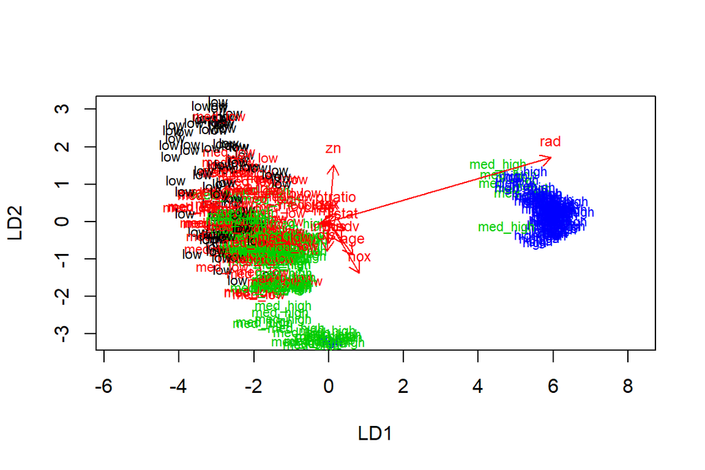

```r
# the function for lda biplot arrows
lda.arrows <- function(x, myscale = 1, arrow_heads = 0.1, color = "red", tex = 0.75, choices = c(1,2)){
  heads <- coef(x)
  arrows(x0 = 0, y0 = 0,
         x1 = myscale * heads[,choices[1]],
         y1 = myscale * heads[,choices[2]], col=color, length = arrow_heads)
  text(myscale * heads[,choices], labels = row.names(heads),
       cex = tex, col=color, pos=3)
}

# target classes as numeric
classes <- as.numeric(train$crime)

# plot the lda results
plot(lda.fit, dimen = 2, col =classes, pch=classes)
lda.arrows(lda.fit, myscale = 2)
```

```r
# save the correct classes from test data
correct_classes <- test$crime

# remove the crime variable from test data
test <- dplyr::select(test, -crime)


# predict classes with test data
lda.pred <- predict(lda.fit, newdata = test)

# cross tabulate the results
table(correct = correct_classes, predicted = lda.pred$class)
```

```
##           predicted
## correct    low med_low med_high high
##   low       15      11        1    0
##   med_low    8      20        2    0
##   med_high   1       9       16    0
##   high       0       0        0   19
```

It seems that prediction has hard time to differentiate between low and med_lod categories and also med_low from med_high. Good thing seems to be that high crime rate is predicted correctly 19/19 times. It is more intresting to know which areas tend to have more crime than less crime. Maybe better categorisation could be low, med and high?

## 7. Clusterizatonion

Dataset is standardized which should be done usually when you are using euclidiean distance. There are some cases where you don’t do standardization.

```r
library("GGally")
data("Boston")
# center and standardize variables
boston_scaled <- Boston %>% scale() %>% as.data.frame()
# euclidean distance matrix
dist_eu <- dist(boston_scaled)

# look at the summary of the distances
summary(dist_eu)
```

```
##    Min. 1st Qu.  Median    Mean 3rd Qu.    Max.
##  0.1343  3.4620  4.8240  4.9110  6.1860 14.4000
```

```r
# manhattan distance matrix
dist_man <- dist(boston_scaled, method="manhattan")

# look at the summary of the distances
summary(dist_man)
```

```
##    Min. 1st Qu.  Median    Mean 3rd Qu.    Max.
##  0.2662  8.4830 12.6100 13.5500 17.7600 48.8600
```

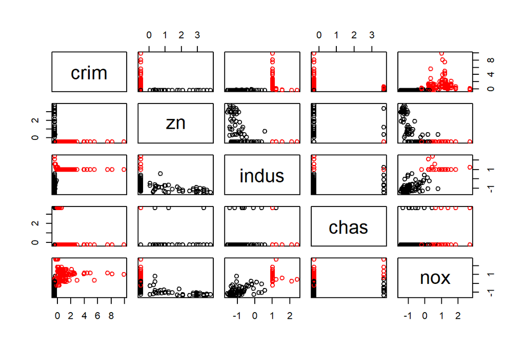

```r
# k-means clustering
km <-kmeans(boston_scaled, centers = 2)

# plot the Boston dataset with clusters
pairs(boston_scaled[1:5], col = km$cluster)
```

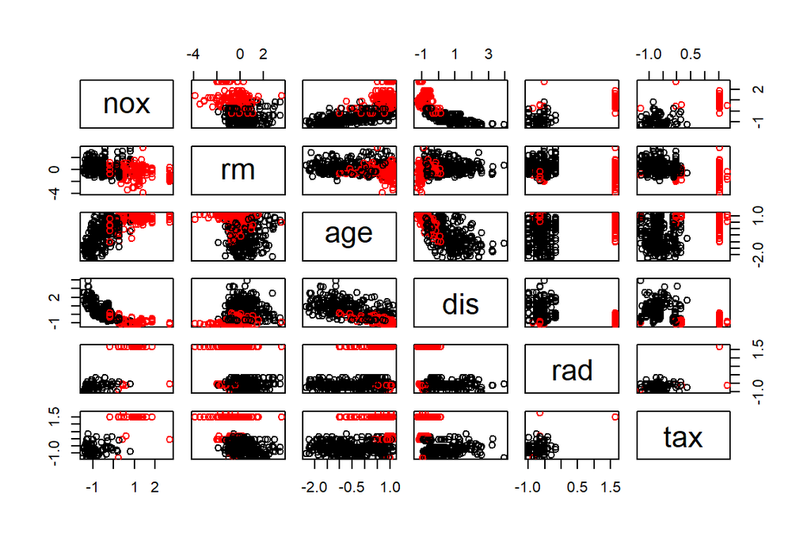

```r
pairs(boston_scaled[5:10], col = km$cluster)
```

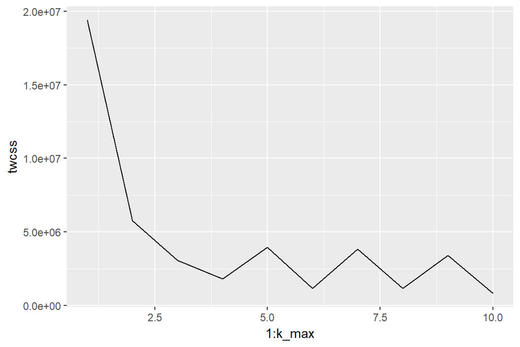

```r
set.seed(123)

# determine the number of clusters
k_max <- 10

# calculate the total within sum of squares
twcss <- sapply(1:k_max, function(k){kmeans(Boston, k)$tot.withinss})

# visualize the results
qplot(x = 1:k_max, y = twcss, geom = 'line')
```

[output not shown]

[figure not shown]

```r
# k-means clustering
km <-kmeans(boston_scaled, centers = 2)

# add new column to data frame

boston_scaled <- boston_scaled %>% mutate(cluster=as.factor(as.character(km$cluster)))
# plot the Boston dataset with clusters
ggpairs(boston_scaled, mapping = aes(col=cluster, alpha=0.3), lower = list(combo = wrap("facethist", bins = 20)))
```

Total within sum of squares tells us that best clusterization can be achieved with two clusters.

Managed to do `ggpairs` plot with the clusters need some tweaking because color variable can’t be numering in ggplot so I had to change it first character and then factor. It seems that two clusters are divided quite well based on tax and nox variables.